# Toronto Uber Movement and Transportation Tomorrow Survey (TTS) Datasets

# Author

- Jordan Bell
- July 24, 2019
- https://jordanbell2357.github.io/TTS.nb.html

```r
library(data.table)
library(dplyr)
library(sp)
library(sf)
library(ggplot2)
library(viridisLite)
library(viridis)
```

# Uber Movement

[Uber Movement](https://movement.uber.com/?lang=en-CA)

GeoJSON file

toronto_neighbourhoods.json

Dataset for Q2 of 2018

toronto-neighbourhoods-2018-2-All-MonthlyAggregate.csv

```r
uber_nbds <- st_read("./toronto_neighbourhoods.json", stringsAsFactors=FALSE)
str(uber_nbds)
```

```
Classes ‘sf’ and 'data.frame':  141 obs. of  3 variables:
 $ MOVEMENT_ID : chr  "1" "2" "3" "4" ...
 $ DISPLAY_NAME: chr  "York University Busway, York University Heights, North York, Toronto" "0 Hambly Avenue, The Beach, Old Toronto, Toronto" "3400 Kingston Road, Scarborough Village, Scarborough, Toronto" "100 Dunn Avenue, Parkdale, Old Toronto, Toronto" ...
 $ geometry    :sfc_MULTIPOLYGON of length 141; first list element: List of 1
  ..$ :List of 1
  .. ..$ : num [1:530, 1:2] -79.5 -79.5 -79.5 -79.5 -79.5 ...
  ..- attr(*, "class")= chr  "XY" "MULTIPOLYGON" "sfg"
 - attr(*, "sf_column")= chr "geometry"
 - attr(*, "agr")= Factor w/ 3 levels "constant","aggregate",..: NA NA
  ..- attr(*, "names")= chr  "MOVEMENT_ID" "DISPLAY_NAME"
```

```r
uber_nbds$ID <- as.integer(uber_nbds$MOVEMENT_ID)
```

```r
uber_nbds$DISPLAY_NAME
```

```
  [1] "York University Busway, York University Heights, North York, Toronto"
  [2] "0 Hambly Avenue, The Beach, Old Toronto, Toronto"
  [3] "3400 Kingston Road, Scarborough Village, Scarborough, Toronto"
  [4] "100 Dunn Avenue, Parkdale, Old Toronto, Toronto"
  [5] "0 Carlaw Avenue, Leslieville, Old Toronto, Toronto"
  [6] "0 Acheson Boulevard, Port Union, Scarborough, Toronto"
  [7] "2800 Kingston Road, Cliffcrest, Scarborough, Toronto"
  [8] "0 Guildwood Parkway, Guildwood, Scarborough, Toronto"
  [9] "0 Avenue of the Island, Old Toronto, Toronto"
 [10] "4200 Lawrence Avenue East, West Hill, Scarborough, Toronto"
 [11] "400 Grandstand Entrance Road, Rexdale, Etobicoke, Toronto"
 [12] "100 Isabella Street, Downtown, Old Toronto, Toronto"
 [13] "0 Rangoon Road, Eringate - Centennial - West Deane, Etobicoke, Toronto"
 [14] "0 Duncairn Road, Don Mills, North York, Toronto"
 [15] "0 McIntosh Street, Cliffside, Scarborough, Toronto"
```

[output cut: 126 more lines]

## Bay Street Corridor

Bay Street Corridor is City of Toronto Neighbourhood 76. This is Uber Neighbourhood 113. We hold fixed this neighbourhood and examine travel times whose destination is to this neighbourhood.

```r
uber_movement <- fread("toronto-neighbourhoods-2018-2-All-MonthlyAggregate.csv")

str(uber_movement)
```

```
Classes ‘data.table’ and 'data.frame':  54366 obs. of  7 variables:
 $ sourceid                                : int  3 135 15 18 53 14 46 16 130 51 ...
 $ dstid                                   : int  65 21 130 100 11 140 4 120 123 31 ...
 $ month                                   : int  5 5 5 5 5 5 5 5 5 5 ...
 $ mean_travel_time                        : num  1675 1861 1778 467 2087 ...
 $ standard_deviation_travel_time          : num  388 424 413 288 800 ...
 $ geometric_mean_travel_time              : num  1635 1815 1732 379 1984 ...
 $ geometric_standard_deviation_travel_time: num  1.24 1.25 1.26 2.02 1.35 1.42 1.66 1.35 1.48 1.38 ...
 - attr(*, ".internal.selfref")=<externalptr>
```

[Introduction to data.table](https://cran.r-project.org/web/packages/data.table/vignettes/datatable-intro.html)

```r
uber_source_113 <- uber_movement[dstid == 113, .(MEAN_TRIP_DURATION = mean(mean_travel_time)), by = .(ID = sourceid)]

str(uber_source_113)
```

```
Classes ‘data.table’ and 'data.frame':  141 obs. of  2 variables:
 $ ID                : int  131 68 54 109 105 4 119 51 110 88 ...
 $ MEAN_TRIP_DURATION: num  2260 2583 1163 1880 1927 ...
 - attr(*, ".internal.selfref")=<externalptr>
```

Robin Lovelace, Jakub Nowosad, and Jannes Muenchow, [Geocomputation with R. Chapter 3: Attribute data operations](https://bookdown.org/robinlovelace/geocompr/attr.html)

```r
uber_source_113_nbds <- left_join(uber_nbds, uber_source_113, by = "ID")

str(uber_source_113_nbds)
```

```
Classes ‘sf’ and 'data.frame':  141 obs. of  5 variables:
 $ MOVEMENT_ID       : chr  "1" "2" "3" "4" ...
 $ DISPLAY_NAME      : chr  "York University Busway, York University Heights, North York, Toronto" "0 Hambly Avenue, The Beach, Old Toronto, Toronto" "3400 Kingston Road, Scarborough Village, Scarborough, Toronto" "100 Dunn Avenue, Parkdale, Old Toronto, Toronto" ...
 $ ID                : int  1 2 3 4 5 6 7 8 9 10 ...
 $ MEAN_TRIP_DURATION: num  2235 941 2259 899 612 ...
 $ geometry          :sfc_MULTIPOLYGON of length 141; first list element: List of 1
  ..$ :List of 1
  .. ..$ : num [1:530, 1:2] -79.5 -79.5 -79.5 -79.5 -79.5 ...
  ..- attr(*, "class")= chr  "XY" "MULTIPOLYGON" "sfg"
 - attr(*, "sf_column")= chr "geometry"
 - attr(*, "agr")= Factor w/ 3 levels "constant","aggregate",..: NA NA NA NA
  ..- attr(*, "names")= chr  "MOVEMENT_ID" "DISPLAY_NAME" "ID" "MEAN_TRIP_DURATION"
```

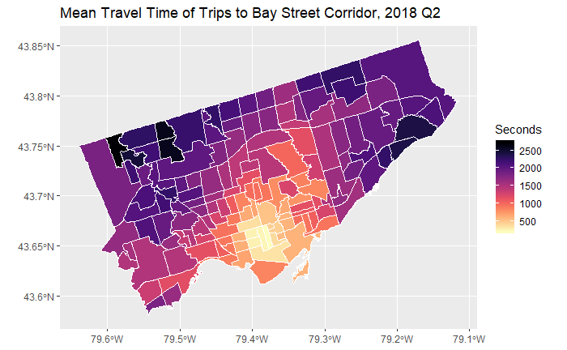

```r
ggplot(uber_source_113_nbds) +
   geom_sf(aes(fill = MEAN_TRIP_DURATION), color = "white") +
  labs(title = "Mean Travel Time of Trips to Bay Street Corridor, 2018 Q2") +
  scale_fill_viridis(option="magma", name="Seconds", direction=-1)
```

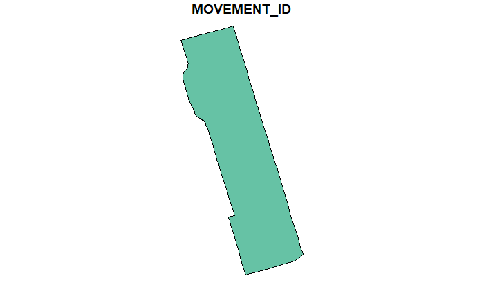

```r
plot(uber_nbds[113,1])
```

## Playter Estates-Danforth

Playter Estates-Danforth is City of Toronto Neighbourhood 67 and Uber Movement Neighbourhood 122.

```r
uber_source_122 <- uber_movement[dstid == 122, .(MEAN_TRIP_DURATION = mean(mean_travel_time)), by = .(ID = sourceid)]

uber_source_122_nbds <- left_join(uber_nbds, uber_source_122, by = "ID")
```

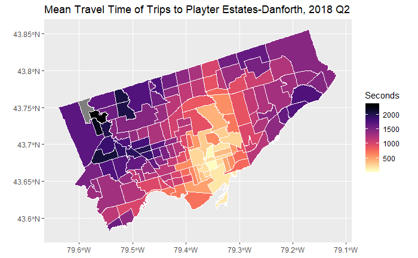

```r
ggplot(uber_source_122_nbds) +
   geom_sf(aes(fill = MEAN_TRIP_DURATION), color = "white") +
  labs(title = "Mean Travel Time of Trips to Playter Estates-Danforth, 2018 Q2") +
  scale_fill_viridis(option="magma", name="Seconds", direction=-1)
```

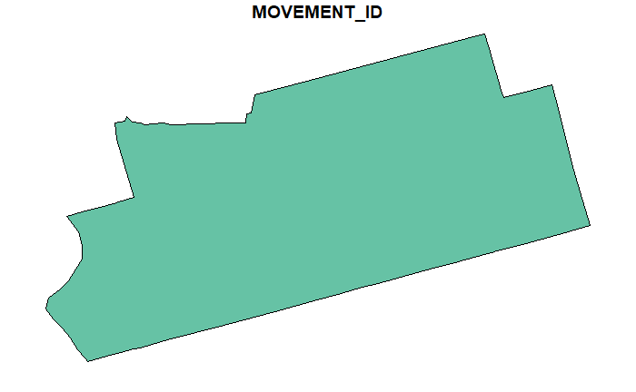

```r
plot(uber_nbds[122,1])
```

# TTS 2016

[Data Management Group, University of Toronto Transportation Research Institute](http://dmg.utoronto.ca/open-data/download-tts-data)

**2016 TTS, City of Toronto**: http://www.dmg.utoronto.ca/csv/tts/tts2016_ward_Toronto.csv

Government of Ontario, [Transportation Tomorrow historical survey data](https://www.ontario.ca/data/transportation-tomorrow-historical-survey-data)

tts_dataset.zip

1986 TTS, 1991 TTS, 1996 TTS, 2001 TTS, 2006 TTS, 2011 TTS, 2016 TTS

## Data Manipulation and Variable Selection

```r
TTS2016_csv <- fread("tts2016_ward_Toronto.csv")

str(TTS2016_csv)
```

```
Classes ‘data.table’ and 'data.frame':  419 obs. of  46 variables:
 $ Region : chr  "Total Number of households" "Number of houses" "Number of apartments" "Number of townhouses" ...
 $ Toronto: chr  "1112970" "343197" "704502" "65271" ...
 $ Ward 1 : chr  "17876" "5607" "10049" "2220" ...
 $ Ward 2 : chr  "20025" "8047" "10628" "1350" ...
 $ Ward 3 : chr  "20081" "10098" "8798" "1185" ...
 $ Ward 4 : chr  "21460" "10060" "10716" "684" ...
 $ Ward 5 : chr  "30650" "11774" "17741" "1135" ...
 $ Ward 6 : chr  "32584" "9256" "21946" "1382" ...
 $ Ward 7 : chr  "17181" "7190" "8713" "1278" ...
 $ Ward 8 : chr  "17926" "3614" "11596" "2716" ...
 $ Ward 9 : chr  "16466" "7321" "8449" "696" ...
 $ Ward 10: chr  "25736" "7386" "17803" "547" ...
 $ Ward 11: chr  "24924" "8551" "15243" "1130" ...
 $ Ward 12: chr  "21407" "7825" "13394" "188" ...
```

[output cut: 33 more lines]

> - [55] “Total Number of persons”
> - [79] “Number of persons without a driver’s licence”
> - [80] “Number of persons with a driver’s licence”
> - [84] “Number of persons with a TTC metro pass”
> - [85] “Number of persons without any transit pass”
> - [147] “Total number of trips made by residents in 24-hour”
> - [156] “Number of trips by residents by walk mode in 24-hour”
> - [157] “Number of trips by residents by bicycle in 24-hour”
> - [416] “Number of transit trips made by residents with TTC Subway/RT”
> - [417] “Number of transit trips made by residents with TTC Bus/Streetcar”

```r
TTS2016_selected <- TTS2016_csv[c(55,79,80,84,85,147,156,157,416,417),]

TTS2016_transpose <- transpose(TTS2016_selected)

v <- as.vector(as.matrix(TTS2016_transpose)[1,])

str(v)
```

```
 chr [1:10] "Total Number of persons" "Number of persons without a driver's licence" ...
```

```r
TTS2016_table <- TTS2016_transpose[-c(1:2),]

colnames(TTS2016_table) <- v

TTS2016_df <- as.data.frame(TTS2016_table)

for (y in v){
  TTS2016_df[,y] <- as.numeric(TTS2016_df[, y])
}

str(TTS2016_df)
```

```
'data.frame':   44 obs. of  10 variables:
 $ Total Number of persons                                         : num  58143 57366 52165 54630 69706 ...
 $ Number of persons without a driver's licence                    : num  25473 22845 15209 17131 20624 ...
 $ Number of persons with a driver's licence                       : num  31764 33277 36399 36443 47950 ...
 $ Number of persons with a TTC metro pass                         : num  5584 4608 3764 5569 8292 ...
 $ Number of persons without any transit pass                      : num  47216 45986 44290 44886 51767 ...
 $ Total number of trips made by residents in 24-hour              : num  89018 100340 110739 114533 153310 ...
 $ Number of trips by residents by walk mode in 24-hour            : num  10159 4003 5242 3892 8371 ...
 $ Number of trips by residents by bicycle in 24-hour              : num  242 265 850 665 1683 ...
 $ Number of transit trips made by residents with TTC Subway/RT    : num  6468 7344 11422 12012 28552 ...
 $ Number of transit trips made by residents with TTC Bus/Streetcar: num  16396 17390 14248 17510 18839 ...
```

```r
TTS2016_df$SCODE_NAME <- c(1:44)

str(TTS2016_df)
```

```
'data.frame':   44 obs. of  11 variables:
 $ Total Number of persons                                         : num  58143 57366 52165 54630 69706 ...
 $ Number of persons without a driver's licence                    : num  25473 22845 15209 17131 20624 ...
 $ Number of persons with a driver's licence                       : num  31764 33277 36399 36443 47950 ...
 $ Number of persons with a TTC metro pass                         : num  5584 4608 3764 5569 8292 ...
 $ Number of persons without any transit pass                      : num  47216 45986 44290 44886 51767 ...
 $ Total number of trips made by residents in 24-hour              : num  89018 100340 110739 114533 153310 ...
 $ Number of trips by residents by walk mode in 24-hour            : num  10159 4003 5242 3892 8371 ...
 $ Number of trips by residents by bicycle in 24-hour              : num  242 265 850 665 1683 ...
 $ Number of transit trips made by residents with TTC Subway/RT    : num  6468 7344 11422 12012 28552 ...
 $ Number of transit trips made by residents with TTC Bus/Streetcar: num  16396 17390 14248 17510 18839 ...
 $ SCODE_NAME                                                      : int  1 2 3 4 5 6 7 8 9 10 ...
```

```r
TTS2016_df$TRIPS_PER_DAY <- TTS2016_df$`Total number of trips made by residents in 24-hour`/
  TTS2016_df$`Total Number of persons`

TTS2016_df$DRIVERS_LICENCE <- TTS2016_df$`Number of persons with a driver's licence`/
  TTS2016_df$`Total Number of persons`

TTS2016_df$TTC_PASS <- TTS2016_df$`Number of persons with a TTC metro pass`/
  TTS2016_df$`Total Number of persons`

TTS2016_df$WALKS_PER_DAY <- TTS2016_df$`Number of trips by residents by walk mode in 24-hour`/
  TTS2016_df$`Total Number of persons`

TTS2016_df$BIKES_PER_DAY <- TTS2016_df$`Number of trips by residents by bicycle in 24-hour`/
  TTS2016_df$`Total Number of persons`
```

## Plotting by Wards

[City of Toronto Wards](https://www.toronto.ca/city-government/data-research-maps/open-data/open-data-catalogue/#29b6fadf-0bd6-2af9-4a8c-8c41da285ad7)

```r
wards <- st_read("C:/Users/14165/Desktop/Shapefiles/May2010_WGS84/icitw_wgs84.shp", stringsAsFactors=FALSE)
str(wards)
```

```
Classes ‘sf’ and 'data.frame':  44 obs. of  11 variables:
 $ GEO_ID    : int  14630026 14630028 14630024 14630027 14630035 14630029 14630036 14630037 14630039 14630031 ...
 $ CREATE_ID : int  63519 63519 63519 63519 63519 63519 63519 63519 63519 63519 ...
 $ NAME      : chr  "Scarborough-Rouge River (41)" "Scarborough East (44)" "Scarborough-Rouge River (42)" "Scarborough-Agincourt (39)" ...
 $ SCODE_NAME: chr  "41" "44" "42" "39" ...
 $ LCODE_NAME: chr  "EA41" "EA44" "EA42" "EA39" ...
 $ TYPE_DESC : chr  "Ward" "Ward" "Ward" "Ward" ...
 $ TYPE_CODE : chr  "CITW" "CITW" "CITW" "CITW" ...
 $ OBJECTID  : int  1 2 3 4 5 6 7 8 9 10 ...
 $ SHAPE_AREA: num  0 0 0 0 0 0 0 0 0 0 ...
 $ SHAPE_LEN : num  0 0 0 0 0 0 0 0 0 0 ...
 $ geometry  :sfc_POLYGON of length 44; first list element: List of 1
  ..$ : num [1:410, 1:2] -79.3 -79.3 -79.3 -79.3 -79.3 ...
  ..- attr(*, "class")= chr  "XY" "POLYGON" "sfg"
 - attr(*, "sf_column")= chr "geometry"
 - attr(*, "agr")= Factor w/ 3 levels "constant","aggregate",..: NA NA NA NA NA NA NA NA NA NA
  ..- attr(*, "names")= chr  "GEO_ID" "CREATE_ID" "NAME" "SCODE_NAME" ...
```

```r
wards$SCODE_NAME <- as.integer(wards$SCODE_NAME)
```

```r
TTS2016_wards <- left_join(wards, TTS2016_df, by = "SCODE_NAME")

str(TTS2016_wards)
```

```
Classes ‘sf’ and 'data.frame':  44 obs. of  26 variables:
 $ GEO_ID                                                          : int  14630026 14630028 14630024 14630027 14630035 14630029 14630036 14630037 14630039 14630031 ...
 $ CREATE_ID                                                       : int  63519 63519 63519 63519 63519 63519 63519 63519 63519 63519 ...
 $ NAME                                                            : chr  "Scarborough-Rouge River (41)" "Scarborough East (44)" "Scarborough-Rouge River (42)" "Scarborough-Agincourt (39)" ...
 $ SCODE_NAME                                                      : int  41 44 42 39 24 40 33 23 8 38 ...
 $ LCODE_NAME                                                      : chr  "EA41" "EA44" "EA42" "EA39" ...
 $ TYPE_DESC                                                       : chr  "Ward" "Ward" "Ward" "Ward" ...
 $ TYPE_CODE                                                       : chr  "CITW" "CITW" "CITW" "CITW" ...
 $ OBJECTID                                                        : int  1 2 3 4 5 6 7 8 9 10 ...
 $ SHAPE_AREA                                                      : num  0 0 0 0 0 0 0 0 0 0 ...
 $ SHAPE_LEN                                                       : num  0 0 0 0 0 0 0 0 0 0 ...
 $ Total Number of persons                                         : num  62727 60284 74745 50098 63305 ...
 $ Number of persons without a driver's licence                    : num  22154 19940 29530 15588 18475 ...
 $ Number of persons with a driver's licence                       : num  38138 39345 43774 32474 43038 ...
 $ Number of persons with a TTC metro pass                         : num  5506 4224 7331 4577 9396 ...
```

[output cut: 17 more lines]

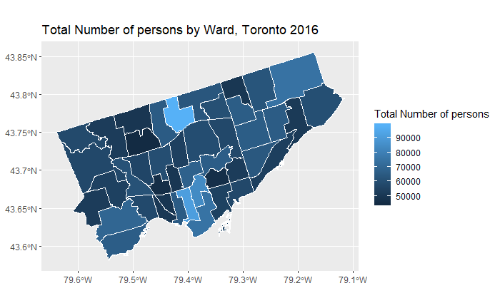

```r
ggplot(TTS2016_wards) +
   geom_sf(aes(fill = `Total Number of persons`), color = "white") +
  labs(title = "Total Number of persons by Ward, Toronto 2016")
```

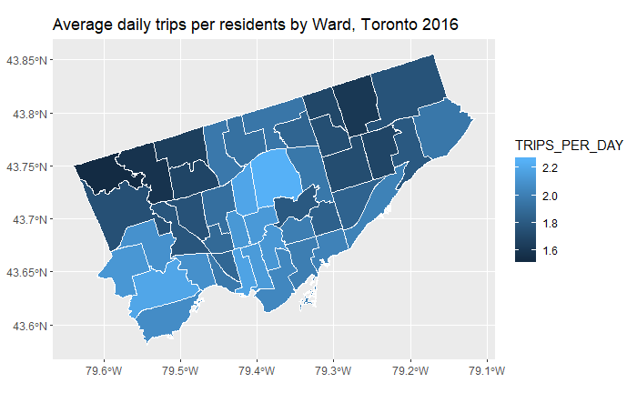

```r
ggplot(TTS2016_wards) +
   geom_sf(aes(fill = TRIPS_PER_DAY), color = "white") +
  labs(title = "Average daily trips per residents by Ward, Toronto 2016")
```

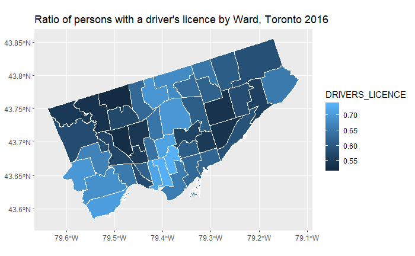

```r
ggplot(TTS2016_wards) +
   geom_sf(aes(fill = DRIVERS_LICENCE), color = "white") +
  labs(title = "Ratio of persons with a driver's licence by Ward, Toronto 2016")
```

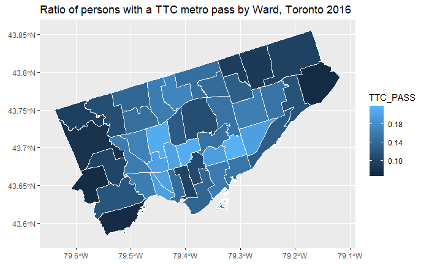

```r
ggplot(TTS2016_wards) +
   geom_sf(aes(fill = TTC_PASS), color = "white") +
  labs(title = "Ratio of persons with a TTC metro pass by Ward, Toronto 2016")
```

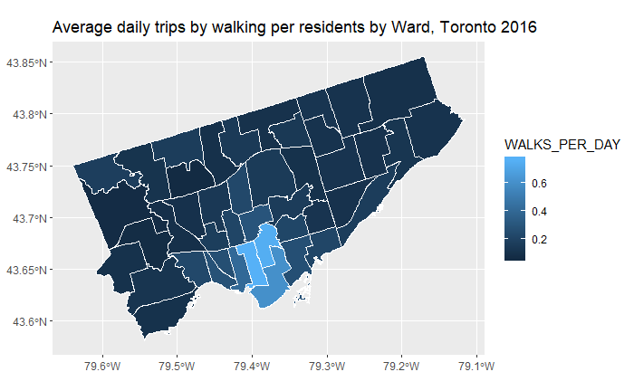

```r
ggplot(TTS2016_wards) +
   geom_sf(aes(fill = WALKS_PER_DAY), color = "white") +
  labs(title = "Average daily trips by walking per residents by Ward, Toronto 2016")
```

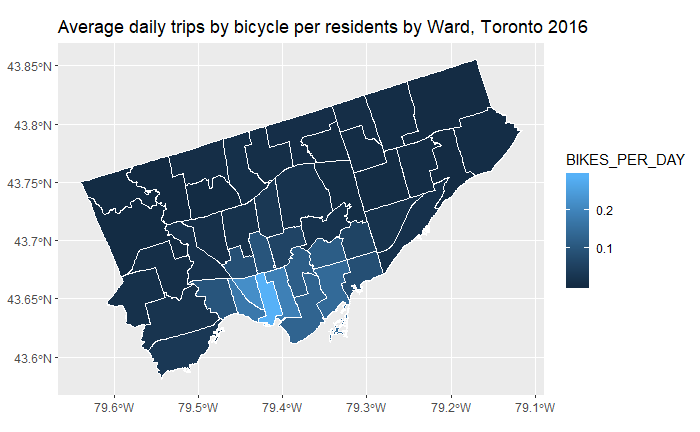

```r
ggplot(TTS2016_wards) +
   geom_sf(aes(fill = BIKES_PER_DAY), color = "white") +
  labs(title = "Average daily trips by bicycle per residents by Ward, Toronto 2016")
```

# Wellbeing Toronto

[Wellbeing Toronto - Transportation](https://www.toronto.ca/city-government/data-research-maps/open-data/open-data-catalogue/#cfa93ad9-7397-e851-f13e-f5097ed0fd55)

WB-Transportation.xlsx

```r
nbds <- st_read("C:/Users/14165/Desktop/Shapefiles/neighbourhoods_planning_areas_wgs84/NEIGHBORHOODS_WGS84.shp", stringsAsFactors=FALSE)
```

```r
nbds$AREA_S_CD <- as.integer(nbds$AREA_S_CD)
```

```r
WB <- read.csv("WB-Transportation.csv")

str(WB)
```

```
'data.frame':   140 obs. of  6 variables:
 $ AREA_S_CD             : int  1 2 3 4 5 6 7 8 9 10 ...
 $ TTC_Stops             : int  338 70 45 40 29 70 81 58 63 61 ...
 $ Non_Traffic_Collisions: int  727 224 109 62 63 105 80 27 39 49 ...
 $ Traffic_Collisions    : int  778 154 69 96 70 74 179 54 150 78 ...
 $ Road_Kilometres       : num  165 33.9 27.9 25.2 17.1 ...
 $ Daily_Road_Volume     : num  5957 3514 3545 7621 4116 ...
```

```r
WB_nbds <- left_join(nbds, WB, by = "AREA_S_CD")

str(WB_nbds)
```

```
Classes ‘sf’ and 'data.frame':  140 obs. of  8 variables:
 $ AREA_S_CD             : int  97 27 38 31 16 118 63 3 55 59 ...
 $ AREA_NAME             : chr  "Yonge-St.Clair (97)" "York University Heights (27)" "Lansing-Westgate (38)" "Yorkdale-Glen Park (31)" ...
 $ TTC_Stops             : int  28 235 44 155 106 55 44 45 62 53 ...
 $ Non_Traffic_Collisions: int  58 598 142 1007 155 260 131 109 256 67 ...
 $ Traffic_Collisions    : int  99 548 173 246 265 171 193 69 154 106 ...
 $ Road_Kilometres       : num  12.8 67.6 39.3 49.7 84.6 ...
 $ Daily_Road_Volume     : num  7116 5546 6920 4194 7115 ...
 $ geometry              :sfc_POLYGON of length 140; first list element: List of 1
  ..$ : num [1:93, 1:2] -79.4 -79.4 -79.4 -79.4 -79.4 ...
  ..- attr(*, "class")= chr  "XY" "POLYGON" "sfg"
 - attr(*, "sf_column")= chr "geometry"
 - attr(*, "agr")= Factor w/ 3 levels "constant","aggregate",..: NA NA NA NA NA NA NA
  ..- attr(*, "names")= chr  "AREA_S_CD" "AREA_NAME" "TTC_Stops" "Non_Traffic_Collisions" ...
```

## Plotting by Neighbourhoods

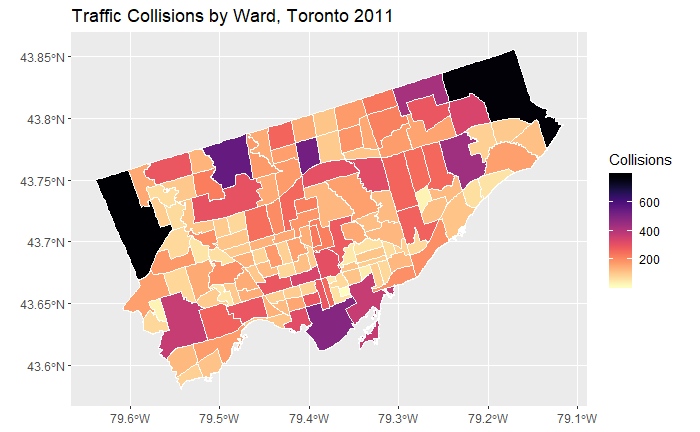

```r
ggplot(WB_nbds) +
   geom_sf(aes(fill = Traffic_Collisions), color = "white") +
  labs(title = "Traffic Collisions by Ward, Toronto 2011") +
  scale_fill_viridis(option="magma", name="Collisions", direction=-1)
```

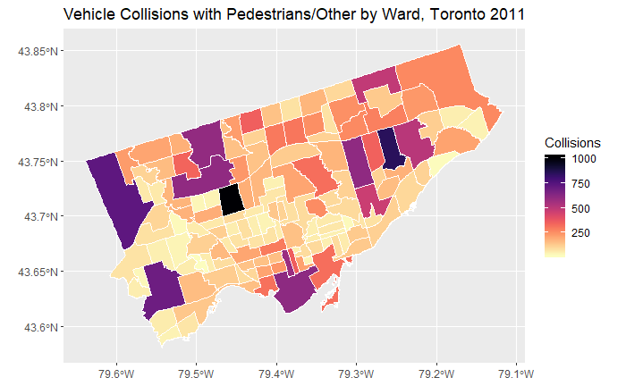

```r
ggplot(WB_nbds) +
   geom_sf(aes(fill = Non_Traffic_Collisions), color = "white") +
  labs(title = "Vehicle Collisions with Pedestrians/Other by Ward, Toronto 2011") +
    scale_fill_viridis(option="magma", name="Collisions", direction=-1)
```

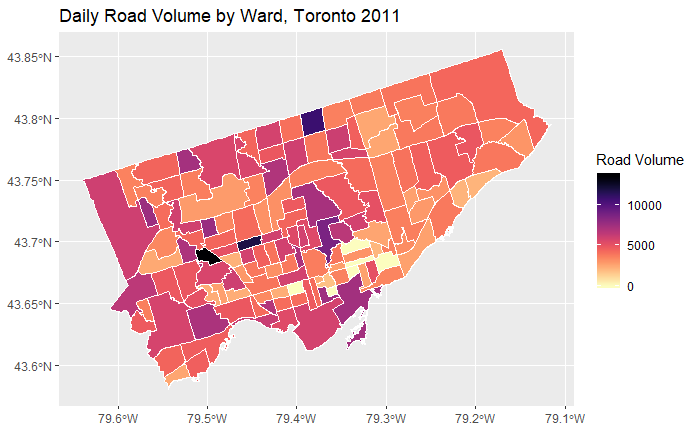

```r
ggplot(WB_nbds) +
   geom_sf(aes(fill = Daily_Road_Volume), color = "white") +
  labs(title = "Daily Road Volume by Ward, Toronto 2011") +
    scale_fill_viridis(option="magma", name="Road Volume", direction=-1)
```